# Evolución de la esperanza de vida y desarrollo económico

Gemma Planas

2026-08-11

# 1. Introducción

## Objetivo principal

El objetivo principal de este proyecto es analizar la evolución de la esperanza de vida a nivel mundial y estudiar su relación con el desarrollo económico de los países entre 1952 y 2007, utilizando datos de Gapminder.

## Objetivos específicos

Los objetivos específicos del proyecto son:

1. Analizar la evolución temporal de la esperanza de vida.
2. Comparar la esperanza de vida media entre continentes.
3. Analizar la relación entre el PIB per cápita y la esperanza de vida.
4. Describir los principales indicadores de la base de datos.
5. Generar resultados reproducibles mediante código R.

# 2. Datos y metodología

Para realizar el análisis se ha utilizado la base de datos Gapminder, que contiene información sobre diferentes indicadores socioeconómicos de distintos países a lo largo del tiempo.

La base de datos utilizada contiene información de **142 países**, pertenecientes a **5 continentes**, durante el periodo comprendido entre **1952 y 2007**.

Las principales variables utilizadas son:

- `country`: país.
- `continent`: continente.
- `year`: año.
- `lifeExp`: esperanza de vida.
- `pop`: población.
- `gdpPercap`: PIB per cápita.

Los datos fueron previamente explorados y depurados mediante código R. Durante este proceso se comprobaron las dimensiones de la base, los valores perdidos, los posibles duplicados y las categorías disponibles.

También se crearon nuevas variables relacionadas con la década y el nivel económico de los países.

# 3. Resultados

## 3.1. Evolución de la esperanza de vida

En primer lugar, se analizó la evolución de la esperanza de vida media a lo largo del periodo estudiado.

```r
library(tidyverse)

datos <- read_csv("../data/gapminder_limpio.csv")

evolucion_vida <- datos %>%
  group_by(year) %>%
  summarise(
    esperanza_vida_media = mean(lifeExp),
    .groups = "drop"
  )
```

La siguiente tabla muestra la esperanza de vida media para cada año disponible:

```r
evolucion_vida
```

```
## # A tibble: 12 × 2
##     year esperanza_vida_media
##    <dbl>                <dbl>
##  1  1952                 49.1
##  2  1957                 51.5
##  3  1962                 53.6
##  4  1967                 55.7
##  5  1972                 57.6
##  6  1977                 59.6
##  7  1982                 61.5
##  8  1987                 63.2
##  9  1992                 64.2
## 10  1997                 65.0
## 11  2002                 65.7
## 12  2007                 67.0
```

Para facilitar la interpretación, se representa gráficamente la evolución temporal:

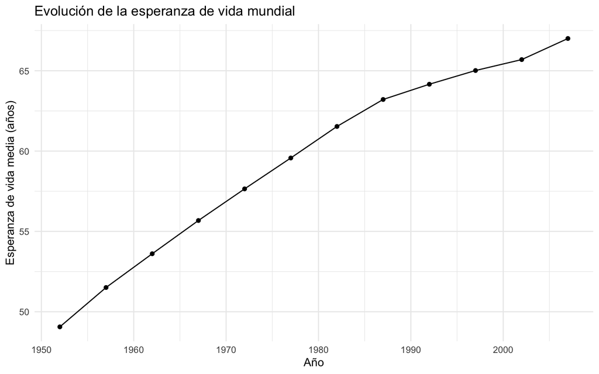

```r
ggplot(
  evolucion_vida,
  aes(x = year, y = esperanza_vida_media)
) +
  geom_line() +
  geom_point() +
  labs(
    title = "Evolución de la esperanza de vida mundial",
    x = "Año",
    y = "Esperanza de vida media (años)"
  ) +
  theme_minimal()
```

La esperanza de vida media presenta una tendencia claramente ascendente durante todo el periodo analizado. En 1952 se situaba aproximadamente en **49,1 años**, mientras que en 2007 alcanzaba aproximadamente **67,0 años**.

Por tanto, durante el periodo estudiado se observa una mejora global de la esperanza de vida.

# 4. Diferencias entre continentes

## 4.1. Esperanza de vida media por continente

A continuación, se calcula la esperanza de vida media para cada continente.

```r
vida_continente <- datos %>%
  group_by(continent) %>%
  summarise(
    esperanza_vida_media = mean(lifeExp),
    .groups = "drop"
  ) %>%
  arrange(desc(esperanza_vida_media))

vida_continente
```

```
## # A tibble: 5 × 2
##   continent esperanza_vida_media
##   <chr>                    <dbl>
## 1 Oceania                   74.3
## 2 Europe                    71.9
## 3 Americas                  64.7
## 4 Asia                      60.1
## 5 Africa                    48.9
```

Los resultados muestran diferencias entre los continentes analizados.

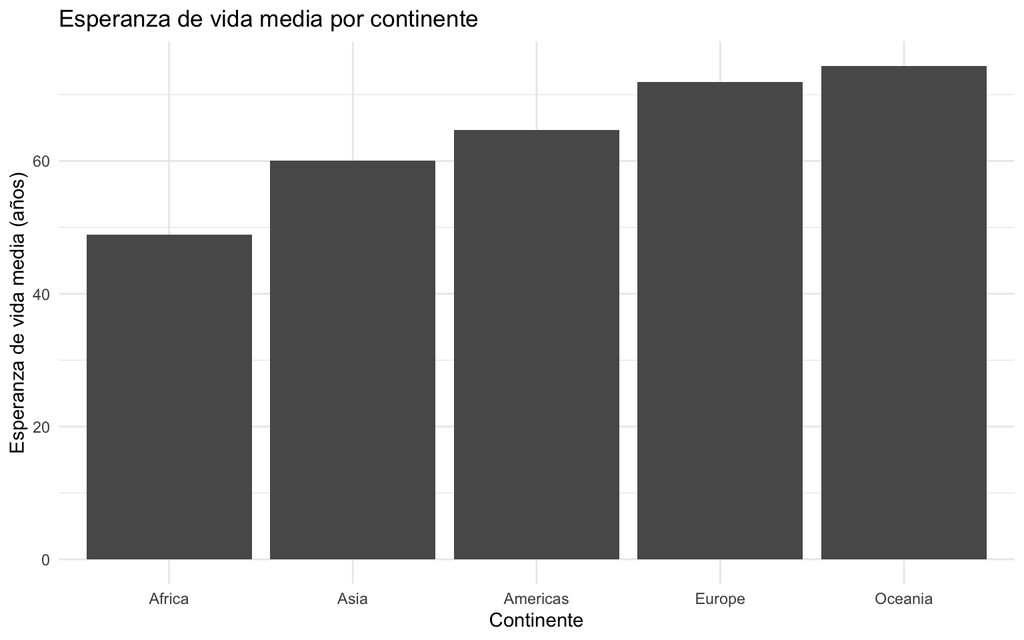

```r
ggplot(
  vida_continente,
  aes(
    x = reorder(continent, esperanza_vida_media),
    y = esperanza_vida_media
  )
) +
  geom_col() +
  labs(
    title = "Esperanza de vida media por continente",
    x = "Continente",
    y = "Esperanza de vida media (años)"
  ) +
  theme_minimal()
```

El gráfico permite observar que la esperanza de vida media no es homogénea entre los diferentes continentes. Estas diferencias pueden estar relacionadas con factores económicos, sociales, sanitarios y demográficos.

# 5. Relación entre PIB per cápita y esperanza de vida

Uno de los objetivos principales del proyecto es estudiar si existe una relación entre el nivel de desarrollo económico y la esperanza de vida.

Para ello se calcula la correlación entre el PIB per cápita y la esperanza de vida.

```r
correlacion <- cor(
  datos$gdpPercap,
  datos$lifeExp
)

correlacion
```

```
## [1] 0.5837062
```

El valor obtenido es aproximadamente **0,584**, lo que indica una **relación positiva moderada** entre ambas variables.

A continuación se representa gráficamente esta relación:

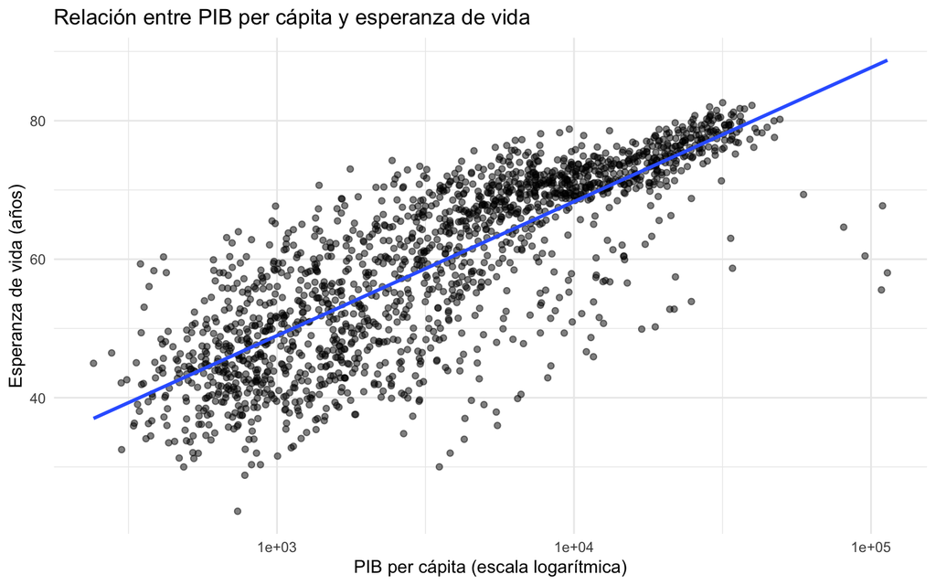

```r
ggplot(
  datos,
  aes(x = gdpPercap, y = lifeExp)
) +
  geom_point(alpha = 0.5) +
  geom_smooth(
    method = "lm",
    se = FALSE
  ) +
  scale_x_log10() +
  labs(
    title = "Relación entre PIB per cápita y esperanza de vida",
    x = "PIB per cápita (escala logarítmica)",
    y = "Esperanza de vida (años)"
  ) +
  theme_minimal()
```

El gráfico muestra una tendencia positiva. En términos generales, los países con un PIB per cápita más elevado tienden a presentar una mayor esperanza de vida.

Sin embargo, es importante señalar que una correlación positiva **no implica causalidad**. Por tanto, los resultados muestran una asociación entre las variables, pero no permiten afirmar que un aumento del PIB provoque directamente un aumento de la esperanza de vida.

# 6. Indicadores principales

Para sintetizar los resultados del proyecto se construye una tabla resumen con los principales indicadores.

```r
resumen <- tibble(
  Indicador = c(
    "Número de países",
    "Número de continentes",
    "Año inicial",
    "Año final",
    "Esperanza de vida inicial",
    "Esperanza de vida final",
    "PIB per cápita medio",
    "Correlación PIB-esperanza de vida"
  ),
  Valor = c(
    n_distinct(datos$country),
    n_distinct(datos$continent),
    min(datos$year),
    max(datos$year),
    round(
      mean(
        datos$lifeExp[
          datos$year == min(datos$year)
        ]
      ),
      1
    ),
    round(
      mean(
        datos$lifeExp[
          datos$year == max(datos$year)
        ]
      ),
      1
    ),
    round(mean(datos$gdpPercap), 0),
    round(correlacion, 3)
  )
)

resumen
```

```
## # A tibble: 8 × 2
##   Indicador                            Valor
##   <chr>                                <dbl>
## 1 Número de países                   142
## 2 Número de continentes                5
## 3 Año inicial                       1952
## 4 Año final                         2007
## 5 Esperanza de vida inicial           49.1
## 6 Esperanza de vida final             67
## 7 PIB per cápita medio              7215
## 8 Correlación PIB-esperanza de vida    0.584
```

Los principales resultados obtenidos son:

- **142 países** incluidos en la base.
- **5 continentes** representados.
- Periodo de estudio de **1952 a 2007**.
- Esperanza de vida media inicial de aproximadamente **49,1 años**.
- Esperanza de vida media final de aproximadamente **67,0 años**.
- PIB per cápita medio de aproximadamente **7.215 USD**.
- Correlación entre PIB per cápita y esperanza de vida de aproximadamente **0,584**.

# 7. Principales hallazgos

Los resultados permiten identificar tres hallazgos principales.

En primer lugar, se observa un **incremento considerable de la esperanza de vida mundial** durante el periodo analizado. La esperanza de vida media aumentó desde aproximadamente 49 años en 1952 hasta 67 años en 2007.

En segundo lugar, existen **diferencias importantes entre continentes**. Esto indica que la evolución de la esperanza de vida no ha sido homogénea a nivel mundial.

Finalmente, se observa una **relación positiva entre el PIB per cápita y la esperanza de vida**. La correlación obtenida, de aproximadamente 0,584, indica una asociación positiva moderada entre ambas variables.

# 8. Conclusiones

El análisis realizado permite concluir que la esperanza de vida experimentó una mejora sustancial entre 1952 y 2007.

Los resultados también muestran diferencias entre continentes y una asociación positiva entre el nivel económico de los países y su esperanza de vida.

En conjunto, los resultados son compatibles con la idea de que los países con mayores niveles de desarrollo económico presentan, en promedio, mejores indicadores de esperanza de vida.

No obstante, el análisis realizado es principalmente descriptivo y correlacional. Por ello, no permite establecer relaciones causales entre las variables estudiadas.

El proyecto demuestra además la utilidad de un flujo de trabajo reproducible mediante R, en el que los datos, el código de análisis, las visualizaciones y el informe técnico pueden mantenerse organizados y actualizados dentro de un mismo proyecto.

# 9. Reproducibilidad

Todo el análisis ha sido desarrollado en RStudio y organizado dentro de un repositorio de GitHub.

La estructura del proyecto permite separar los diferentes componentes del análisis:

- `R/01_limpieza.R`: importación y depuración de los datos.
- `R/02_analisis.R`: análisis estadístico y generación de gráficos.
- `data/gapminder_limpio.csv`: base de datos depurada.
- `dashboard/app.R`: dashboard interactivo.
- `informe/informe_gapminder.Rmd`: informe técnico reproducible.

Esta organización permite que otro usuario pueda acceder al código y reproducir los principales resultados del proyecto.